# House price sales volume prediction

#⚙️Setup

```r
library(mosaic)
library(dplyr)
library(readr)
library(lubridate)
library(tidymodels)
```

#📂opening the dataset

```r
filepath <- "C:/Users/hanam/OneDrive/Desktop/UK house prices/UK-HPI-full-file-2023-06.csv"
uk_hpi <- read_csv(filepath)
```

#🗃️pre-processing data (step 1)

```r
selected_cols    <- c("Date", "RegionName", "12m%Change", "1m%Change", "SalesVolume")

df_uk <-
    uk_hpi %>%
    select(all_of(selected_cols)) %>%
    rename(date = Date, region = RegionName, yearly_change = `12m%Change`, monthly_change = `1m%Change`) %>%
  filter(region == "United Kingdom") %>%
    drop_na() %>%
    mutate(date = lubridate::dmy(date))

df_uk  %>% head(8) %>% knitr::kable()
```

| date | region | yearly_change | monthly_change | SalesVolume |
| --- | --- | --- | --- | --- |
| 2005-01-01 | United Kingdom | 9.970458 | -0.0671141 | 65834.33 |
| 2005-02-01 | United Kingdom | 10.929822 | -0.0961104 | 67225.33 |
| 2005-03-01 | United Kingdom | 11.590248 | 0.8204001 | 81297.33 |
| 2005-04-01 | United Kingdom | 8.263182 | 1.4218673 | 97184.67 |
| 2005-05-01 | United Kingdom | 8.117394 | 1.0736741 | 97785.67 |
| 2005-06-01 | United Kingdom | 7.092794 | 0.7937524 | 111973.67 |
| 2005-07-01 | United Kingdom | 6.196687 | 1.2876797 | 117771.33 |
| 2005-08-01 | United Kingdom | 5.415964 | 0.4065795 | 114613.33 |

#adding lagged variables

```r
df_uk <-
    df_uk %>%
    arrange(date) %>%
    mutate(SalesVolume1 = lag(SalesVolume, 1)) %>%
   mutate(monthly_changes_lag1 = lag(monthly_change, 1)) %>%
    drop_na() %>%
    arrange(desc(date))
```

#separating data- testing/training data sets

```r
df_uk_train <- df_uk %>% filter(date <   ymd("2020-01-01"))
df_uk_test  <- df_uk %>% filter(date >=  ymd("2020-01-01"))
```

Here I am creating a training set (df_uk_train) which contains all data for the UK up until December 2019, and a testing set (df_uk_test) contain data from January 2020 onwards.

# linear regression- Sales volume increase per month

#Building linear model- model 1

Here I am building a linear model in which ‘SalesVolume’ is our outcome variable and ‘SalesVolume1’ (lagged sales volume) is our predictor, in order to measure change in sales volume per 1 month.

```r
model1 <-
  linear_reg() %>%
    set_engine("lm") %>%
    fit(SalesVolume ~ SalesVolume1, data = df_uk_train)
```

```r
##model coefficients
model1 %>% tidy()
```

```
# A tibble: 2 × 5
  term          estimate std.error statistic  p.value
  <chr>            <dbl>     <dbl>     <dbl>    <dbl>
1 (Intercept)  13633.    3540.          3.85 1.64e- 4
2 SalesVolume1     0.837    0.0409     20.5  1.64e-48
```

```r
##full model summary
model1$fit %>% summary()
```

```
Call:
stats::lm(formula = SalesVolume ~ SalesVolume1, data = data)

Residuals:
   Min     1Q Median     3Q    Max
-65411  -6028    890   7037  60945

Coefficients:
              Estimate Std. Error t value Pr(>|t|)
(Intercept)  1.363e+04  3.540e+03   3.851 0.000164 ***
SalesVolume1 8.372e-01  4.092e-02  20.459  < 2e-16 ***
---
Signif. codes:  0 '***' 0.001 '**' 0.01 '*' 0.05 '.' 0.1 ' ' 1

Residual standard error: 13260 on 177 degrees of freedom
Multiple R-squared:  0.7028,    Adjusted R-squared:  0.7011
F-statistic: 418.6 on 1 and 177 DF,  p-value: < 2.2e-16
```

```r
#Overall statistics
model1 %>% glance()
```

```
# A tibble: 1 × 12
  r.squared adj.r.squared  sigma statistic  p.value    df logLik   AIC   BIC
      <dbl>         <dbl>  <dbl>     <dbl>    <dbl> <dbl>  <dbl> <dbl> <dbl>
1     0.703         0.701 13256.      419. 1.64e-48     1 -1952. 3910. 3920.
# ℹ 3 more variables: deviance <dbl>, df.residual <int>, nobs <int>
```

#Building a linear model- model2

```r
model2 <-
  linear_reg() %>%
    set_engine("lm") %>%
    fit(SalesVolume ~ monthly_changes_lag1, data = df_uk_train)
```

```r
##model coefficients
model2 %>% tidy()
```

```
# A tibble: 2 × 5
  term                 estimate std.error statistic   p.value
  <chr>                   <dbl>     <dbl>     <dbl>     <dbl>
1 (Intercept)            79741.     1656.     48.2  1.17e-103
2 monthly_changes_lag1   13999.     1896.      7.38 5.78e- 12
```

```r
##full model summary
model2$fit %>% summary()
```

```
Call:
stats::lm(formula = SalesVolume ~ monthly_changes_lag1, data = data)

Residuals:
   Min     1Q Median     3Q    Max
-47840 -14186   -582  11492  57762

Coefficients:
                     Estimate Std. Error t value Pr(>|t|)
(Intercept)             79741       1656  48.166  < 2e-16 ***
monthly_changes_lag1    13998       1896   7.384 5.78e-12 ***
---
Signif. codes:  0 '***' 0.001 '**' 0.01 '*' 0.05 '.' 0.1 ' ' 1

Residual standard error: 21260 on 177 degrees of freedom
Multiple R-squared:  0.2355,    Adjusted R-squared:  0.2312
F-statistic: 54.53 on 1 and 177 DF,  p-value: 5.777e-12
```

```r
#Overall statistics
model2 %>% glance()
```

```
# A tibble: 1 × 12
  r.squared adj.r.squared  sigma statistic  p.value    df logLik   AIC   BIC
      <dbl>         <dbl>  <dbl>     <dbl>    <dbl> <dbl>  <dbl> <dbl> <dbl>
1     0.236         0.231 21261.      54.5 5.78e-12     1 -2037. 4079. 4089.
# ℹ 3 more variables: deviance <dbl>, df.residual <int>, nobs <int>
```

## 📈Plots/diagrams

#Training set-model 1

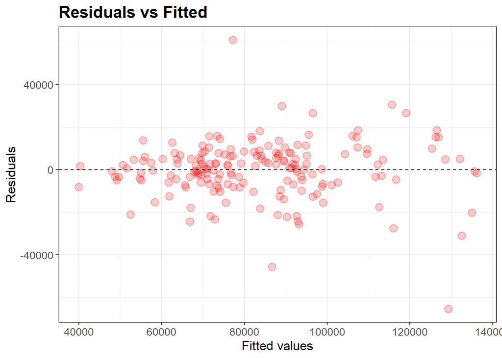

```r
plot_df <- model1 %>% augment(df_uk_train)
g <- ggplot(plot_df, aes(x = .pred, y = .resid)) +
    geom_point(alpha=0.2, size=3, color="red", stroke=1) +
    geom_hline(yintercept = 0, linetype = "dashed") +
    labs(x = "Fitted values", y = "Residuals", title="Residuals vs Fitted") +
    theme_bw() +
    theme(axis.title.x = element_text(size = rel(1.2)),
          axis.text.x = element_text(size = rel(1.2)),
          axis.title.y = element_text(size = rel(1.2)),
          axis.text.y = element_text(size = rel(1.2)),
          plot.title = element_text(size = rel(1.5), face = "bold"))
g
```

The model appears to be a good fit, as the residual plot is linear.

#Testing set- model 1

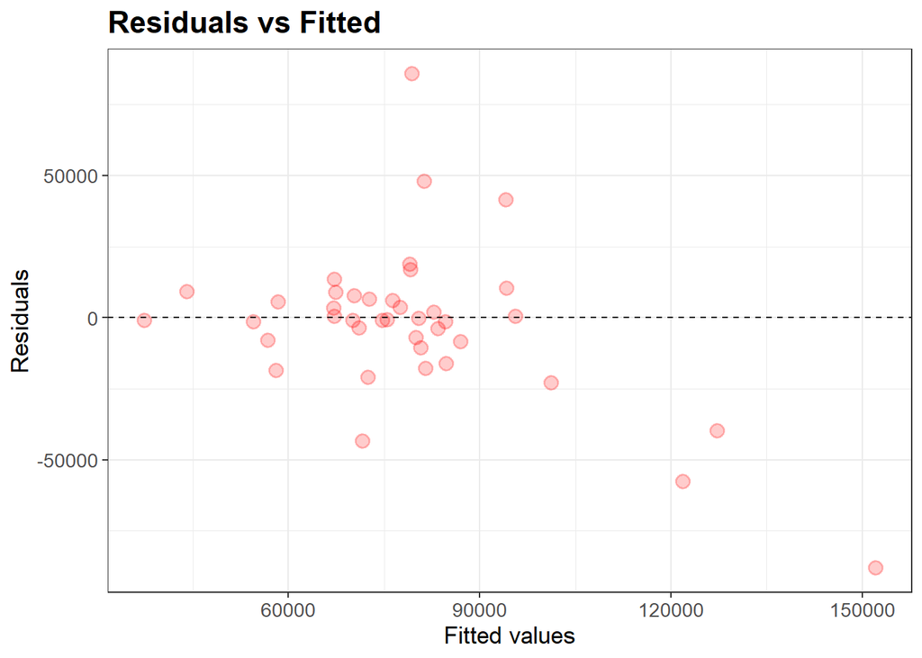

```r
ggplot(model1 %>% augment(df_uk_test), aes(.pred, .resid)) +
    geom_point(alpha=0.2, size=3, color="red", stroke=1) +
    geom_hline(yintercept = 0, linetype = "dashed") +
    labs(x = "Fitted values", y = "Residuals", title="Residuals vs Fitted") +
    theme_bw() +
    theme(axis.title.x = element_text(size = rel(1.2)),
          axis.text.x = element_text(size = rel(1.2)),
          axis.title.y = element_text(size = rel(1.2)),
          axis.text.y = element_text(size = rel(1.2)),
          plot.title = element_text(size = rel(1.5), face = "bold"))
```

The model also appears to be a good fit for the testing data frame. It appears to be linear, however with a slight curvature and a larger scattering than our training set.

#Training set- model 2

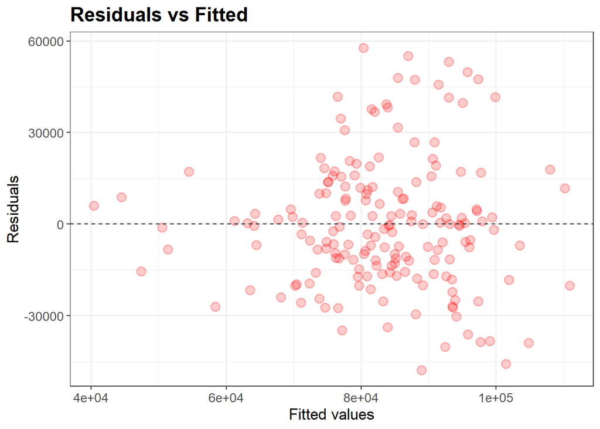

```r
ggplot(model2 %>% augment(df_uk_train), aes(.pred, .resid)) +
    geom_point(alpha=0.2, size=3, color="red", stroke=1) +
    geom_hline(yintercept = 0, linetype = "dashed") +
    labs(x = "Fitted values", y = "Residuals", title="Residuals vs Fitted") +
    theme_bw() +
    theme(axis.title.x = element_text(size = rel(1.2)),
          axis.text.x = element_text(size = rel(1.2)),
          axis.title.y = element_text(size = rel(1.2)),
          axis.text.y = element_text(size = rel(1.2)),
          plot.title = element_text(size = rel(1.5), face = "bold"))
```

In comparison to our ‘SalesVolume/SalesVolume1’ lagged model, model 2 is less linear and highly scattered.

#Testing set- model 2

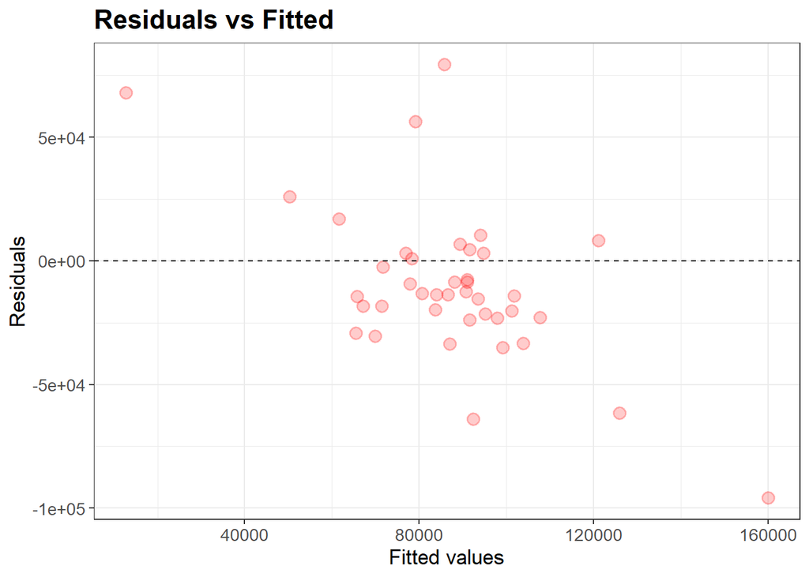

```r
ggplot(model2 %>% augment(df_uk_test), aes(.pred, .resid)) +
    geom_point(alpha=0.2, size=3, color="red", stroke=1) +
    geom_hline(yintercept = 0, linetype = "dashed") +
    labs(x = "Fitted values", y = "Residuals", title="Residuals vs Fitted") +
    theme_bw() +
    theme(axis.title.x = element_text(size = rel(1.2)),
          axis.text.x = element_text(size = rel(1.2)),
          axis.title.y = element_text(size = rel(1.2)),
          axis.text.y = element_text(size = rel(1.2)),
          plot.title = element_text(size = rel(1.5), face = "bold"))
```

There doesn’t appear to be much of a linear relationship between our variables in model 2 testing set.

# Evaluating model:

#🖩Calculating MAE- Training set/model 1

The mean absolute error allows us to distinguish how far the model is off from a true observation.

```r
model1 %>%
    augment(df_uk_train) %>%
    mae(truth = SalesVolume, estimate = .pred)
```

```
# A tibble: 1 × 3
  .metric .estimator .estimate
  <chr>   <chr>          <dbl>
1 mae     standard       9195.
```

```r
favstats(~SalesVolume, data = df_uk)
```

```
      min       Q1 median       Q3    max    mean       sd   n missing
 28356.33 66830.67  78518 94480.67 165290 82035.4 24534.11 219       0
```

#Calculating MAE- Testing set/model 1

```r
model1%>%
    augment(df_uk_test) %>%
    mae(truth = SalesVolume, estimate = .pred)
```

```
# A tibble: 1 × 3
  .metric .estimator .estimate
  <chr>   <chr>          <dbl>
1 mae     standard      16550.
```

The MAE for the testing set is significantly larger than the training set, indicating that the model is not generalizing well to the rest of our dataset.

#Calculating MAE- training set/model 2

```r
model2%>%
    augment(df_uk_train) %>%
    mae(truth = SalesVolume, estimate = .pred)
```

```
# A tibble: 1 × 3
  .metric .estimator .estimate
  <chr>   <chr>          <dbl>
1 mae     standard      16240.
```

Our second linear model has a larger MAE than model 1, additionally the training set doesn’t seem to fit the linear model well.

#Calculating MAE- testing set/model 2

```r
model2%>%
    augment(df_uk_test) %>%
    mae(truth = SalesVolume, estimate = .pred)
```

```
# A tibble: 1 × 3
  .metric .estimator .estimate
  <chr>   <chr>          <dbl>
1 mae     standard      24204.
```

# Commentary

I ran a linear model with the outcome variable as ‘SalesVolume’ and the explanatory variable as ‘SalesVolume1’ (i.e., the lagged sales volume). This made up my first model. By creating a linear regression with these variables we can analyze the monthly lag/ change in sales volume per 1 month. Running a regression between a variable and their lagged counterpart is necessary for analyze time-lapsed relationships hence why this was my first model. The MAE was relatively small for our training model but not testing set, indicating the linear model is potentially overfitted.

From this I can conclude model 1 was closer to a true model in analyzing sales volume per month.